# Course project

John Clifford

27/04/2021

## Introduction

In this document we will obtain data from accelerometers on the belt, forearm, arm, and dumbell of 6 participants who performed barbell lifts correctly and incorrectly in 5 different ways.

## Data processing

First let’s get the data:

```r
library(caret)
library(dplyr)
library(tidyr)
library(randomForest)
library(e1071)
library(rpart)
url<- ("https://d396qusza40orc.cloudfront.net/predmachlearn/pml-training.csv")
dest<- ("./training.csv")
#download.file(url,dest)
dataset <- read.csv(dest,na.strings=c('','NA'))
```

There are a lot of blank columns in our dataset. We can see this here

```r
library(naniar)
empty<- miss_var_summary(dataset, show_pct= TRUE)
empty_max<- subset(empty, empty$pct_miss>90)
head(empty_max)
```

```
## # A tibble: 6 x 3
##   variable             n_miss pct_miss
##   <chr>                 <int>    <dbl>
## 1 kurtosis_roll_belt    19216     97.9
## 2 kurtosis_picth_belt   19216     97.9
## 3 kurtosis_yaw_belt     19216     97.9
## 4 skewness_roll_belt    19216     97.9
## 5 skewness_roll_belt.1  19216     97.9
## 6 skewness_yaw_belt     19216     97.9
```

```r
dim(empty_max)
```

```
## [1] 100   3
```

We should remove these empty columns.

```r
emptycols<- empty_max$variable
`%ni%` <- Negate(`%in%`)
dataset<- subset(dataset, select=(names(dataset) %ni% emptycols))
```

Our first 6 variables relate to time, username and number of observation, so we can also remove these.

```r
dataset <- dataset[-c(1:6)]
```

We now have 54 variables; Our algorithms do not handle missing values well. So we check there are no incomplete observations.

```r
dim(dataset)
```

```
## [1] 19622    54
```

```r
dataset<- na.omit(dataset)
dim(dataset)
```

```
## [1] 19622    54
```

## Cross validation

We will divide our dataset into training and validation sets and set a seed for reproducibility.

```r
set.seed(343)
inTrain = createDataPartition(dataset$classe, p = 0.6)[[1]]
training = dataset[ inTrain,]
valid = dataset[-inTrain,]
dim(training)
```

```
## [1] 11776    54
```

```r
dim(valid)
```

```
## [1] 7846   54
```

For all models we will use a 5 fold cross validation approach.

```r
trCtrl <- trainControl(method = "cv", number = 5)
```

We now have a training set and a validation set. However, we will be using our validation set to select our model. This means we should hold back some data to test the chosen model. We will call this the holdout set.

```r
inTrain = createDataPartition(valid$classe, p = 0.6)[[1]]
validation = valid[ inTrain,]
holdout = valid[-inTrain,]
```

## Choosing a model

Let’s understand our ‘classe’ variable. We need to understand the distribution of the ‘classe’ variable. We can see that this is in 5 classes A-E, with a higher number of observations in class A. Let’s also set this to be a factor variable in all our datasets.

```r
table(training$classe)
```

```
##
##    A    B    C    D    E
## 3348 2279 2054 1930 2165
```

```r
training$classe<- as.factor(training$classe)
validation$classe<- as.factor(validation$classe)
holdout$classe<- as.factor(holdout$classe)
```

## correlation

We can see some correlation between certain variables.

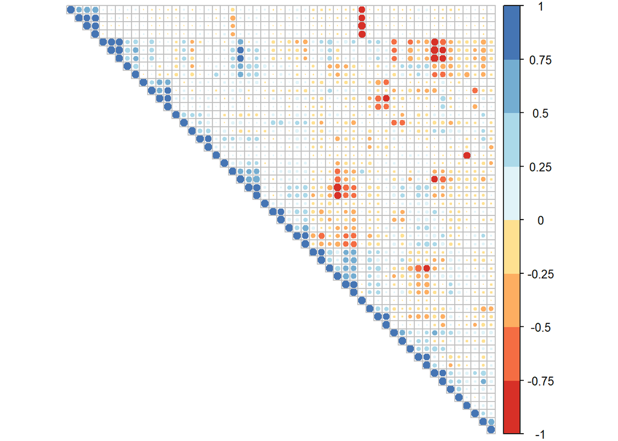

```r
library(corrplot)
library(RColorBrewer)
M <-cor(training[-c(54)])
corrplot(M, type="upper", order="hclust", tl.pos='n',
         col=brewer.pal(n=8, name="RdYlBu"))
```

## Model building

We need a classifier algorithm.

Let’s try Linear Discrimate Analysis. This may have advantages as we observed some correlation between some variables and we have a high number of samples.

```r
model2lda<- train(classe ~.,method="lda",data=training, trControl = trCtrl)
pred2lda<- predict(model2lda, validation)
confusionMatrix(pred2lda, validation$classe)$overall["Accuracy"]
```

```
##  Accuracy
## 0.7174098
```

Now let’s build a basic decision tree. Decision trees are fast and can handle data with non-gaussian distributions. Note that default folds are 10.

```r
model2rprt<- rpart(classe ~ ., data=training, method="class")
pred2rprt<- predict(model2rprt, validation, type="class")
confusionMatrix(pred2rprt, validation$classe)$overall["Accuracy"]
```

```
##  Accuracy
## 0.7549894
```

This performs as well as LDA. However, a random forest model may have an advantage due to the higher dimensionality of the data.

```r
model2rf<- randomForest(classe ~.,data=training, ntree=100, trControl = trCtrl)
pred2rf<- predict(model2rf, validation)
confusionMatrix(pred2rf, validation$classe)$overall["Accuracy"]
```

```
##  Accuracy
## 0.9968153
```

This model performs well with 99.7% accuracy.

Finally we will build a stacked model of these using the random forest method.

```r
predDF <- data.frame(pred2rf,pred2rprt,pred2lda, classe=validation$classe)
combModFit <- randomForest(classe ~.,method="rf",data=predDF, method="class", ntree=100)
ensemble_pred <- data.frame(
                        predict(model2rf, validation),
                        predict(model2rprt, validation, type="class"),
                        predict(model2lda, validation),
                        classe= validation$classe
                        )
names(ensemble_pred)<- names(predDF)


combPred_val <- predict(combModFit,ensemble_pred)
confusionMatrix(combPred_val, validation$classe)$overall["Accuracy"]
```

```
##  Accuracy
## 0.9951168
```

We can see that there is no advantage to this approach, as it does not perform better than the best performing model.

We have selected our random forest predictor. Note we have used the validation dataset to select it, so we need to measure its performance against our holdout set.

```r
pred2rfh<- predict(model2rf, holdout)
confusionMatrix(pred2rfh, holdout$classe)$overall["Accuracy"]
```

```
##  Accuracy
## 0.9961735
```

# Out of sample error

So our model is 99.6% accurate on our holdout set. We would therefore predict an out of sample error of 0.4%.

# Testing

```r
test<- read.csv("./testing.csv",na.strings=c('','NA'))
test_pred <- predict(model2rf, test)
test_pred
```

```
##  1  2  3  4  5  6  7  8  9 10 11 12 13 14 15 16 17 18 19 20
##  B  A  B  A  A  E  D  B  A  A  B  C  B  A  E  E  A  B  B  B
## Levels: A B C D E
```